# Assignment Statistical Modelling

Mariagrazia Di Bartolomeo

2024-05-16

Once we’ve set up the working directory, we’ve imported our dataset.

```r
dataset=read.csv("5304201.csv")
head(dataset)
```

```
##          Y        X1        X2       X3       X4       X5       X6       X7
## 1 76.10578  89.20131  82.55409 58.44656 62.40237 70.26036 81.42871 72.17626
## 2 87.52202  66.17892  87.31489 60.61155 70.96438 69.52281 73.82672 52.80267
## 3 24.79589  83.44045 100.00000 88.99299 88.00290 69.39585 59.89658 80.59149
## 4 33.80966  99.03933  92.77269 56.82227 47.01928 77.78464 61.29054 66.28124
## 5 45.78576  94.62934  65.59269 94.04647 55.66260 37.13717 41.25544 61.04924
## 6 78.19737 100.00000  69.05472 72.85500 62.49019 62.83326 57.63132 70.99912
##         X8        X9      X10      X11       X12       X13      X14 X15 X16 X17
## 1 65.23315  87.37960 82.80871 85.46879  82.97865  98.08375 72.82018   1   0   0
## 2 71.83358  92.71235 68.91234 85.42843 100.00000 100.00000 65.75166   1   0   1
## 3 92.38489  70.03022 80.02115 81.44805  94.69790  79.11218 62.70210   0   0   1
## 4 58.77969  82.46653 85.62839 88.38785  86.75424 100.00000 50.94675   1   0   1
## 5 57.40989  94.49475 66.30911 75.98708 100.00000  74.26846 57.79793   1   1   0
## 6 61.60685 100.00000 73.71356 54.82096  59.88587  72.47705 74.27990   0   0   0
##   X18 X19 X20 X21 X22
## 1   0   0   1   0   1
## 2   0   1   0   0   1
## 3   0   0   0   0   0
## 4   0   1   1   0   0
## 5   0   1   1   0   0
## 6   0   0   0   1   0
```

## PROBLEM 1

```r
attach(dataset)
X_midexams=cbind(X1, X2, X3, X4, X5, X6, X7, X8, X9, X10, X11, X12, X13, X14)
head(X_midexams)
```

```
##             X1        X2       X3       X4       X5       X6       X7       X8
## [1,]  89.20131  82.55409 58.44656 62.40237 70.26036 81.42871 72.17626 65.23315
## [2,]  66.17892  87.31489 60.61155 70.96438 69.52281 73.82672 52.80267 71.83358
## [3,]  83.44045 100.00000 88.99299 88.00290 69.39585 59.89658 80.59149 92.38489
## [4,]  99.03933  92.77269 56.82227 47.01928 77.78464 61.29054 66.28124 58.77969
## [5,]  94.62934  65.59269 94.04647 55.66260 37.13717 41.25544 61.04924 57.40989
## [6,] 100.00000  69.05472 72.85500 62.49019 62.83326 57.63132 70.99912 61.60685
##             X9      X10      X11       X12       X13      X14
## [1,]  87.37960 82.80871 85.46879  82.97865  98.08375 72.82018
## [2,]  92.71235 68.91234 85.42843 100.00000 100.00000 65.75166
## [3,]  70.03022 80.02115 81.44805  94.69790  79.11218 62.70210
## [4,]  82.46653 85.62839 88.38785  86.75424 100.00000 50.94675
## [5,]  94.49475 66.30911 75.98708 100.00000  74.26846 57.79793
## [6,] 100.00000 73.71356 54.82096  59.88587  72.47705 74.27990
```

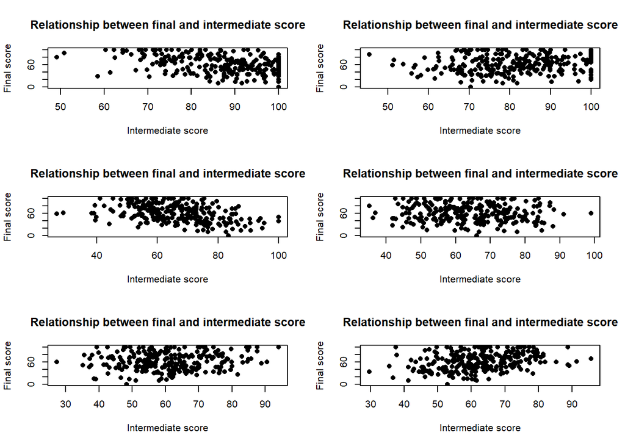

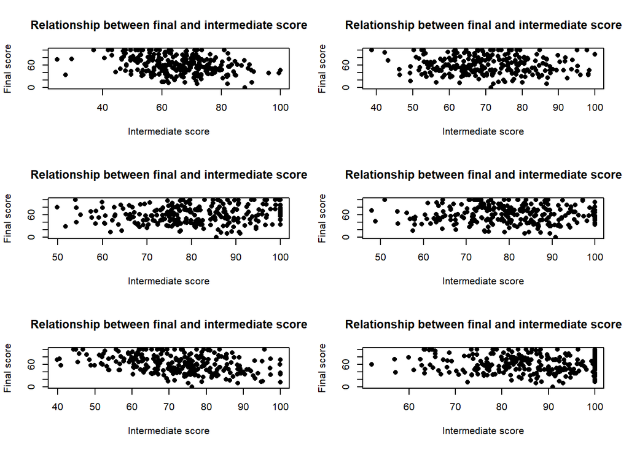

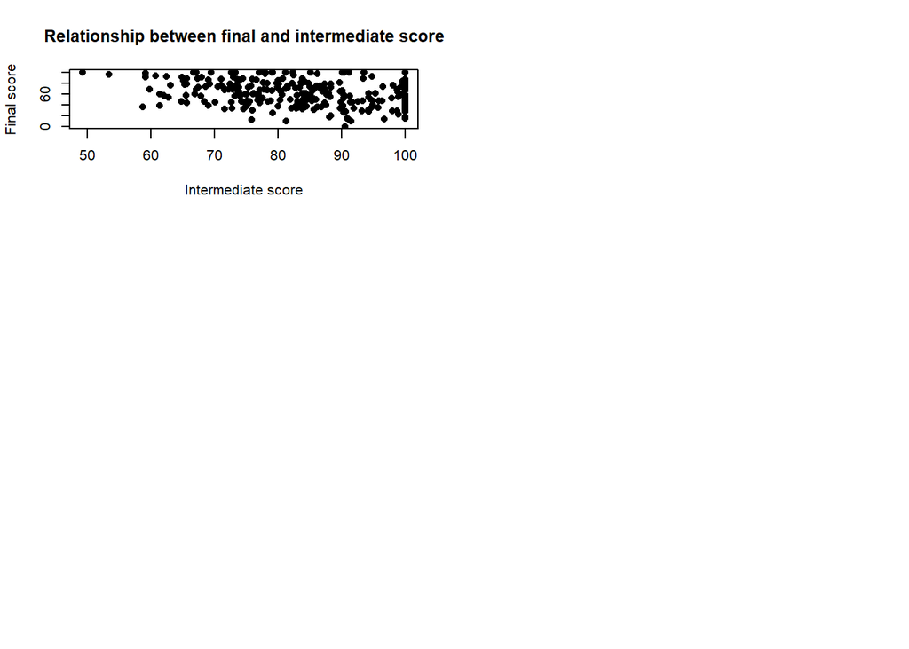

```r
par(mfrow=c(3,2))

for( p in 1:13) {
  plot(X_midexams[,p], Y, xlab ="Intermediate score", ylab="Final score", main = "Relationship between final and intermediate score", pch=16)
}
```

We can observe that these graphs aren’t so clear to explain the relationship between $Y$ and each of the $q$ intermediate scores. For some of them, there appears to be correlation, while for others, there is no clear pattern.

About the second point of the first problem, we’ve created a data frame $predictors$ selecting only categorical predictors (each of ones correspond to one of the training program). Using a loop, we’ve compared through box plots the distribution of $Y$ between the two groups: students who attended and who did not attend the program.

```r
x=as.data.frame(dataset[,c(16:23)])
head(x)
```

```
##   X15 X16 X17 X18 X19 X20 X21 X22
## 1   1   0   0   0   0   1   0   1
## 2   1   0   1   0   1   0   0   1
## 3   0   0   1   0   0   0   0   0
## 4   1   0   1   0   1   1   0   0
## 5   1   1   0   0   1   1   0   0
## 6   0   0   0   0   0   0   1   0
```

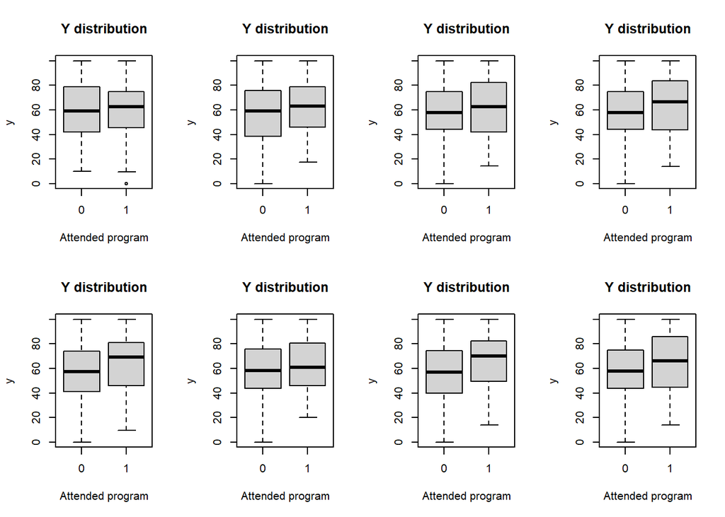

```r
predictors= c("X15", "X16", "X17", "X18", "X19", "X20", "X21", "X22")
par(mfrow=c(2,4))
for(x in predictors){
  boxplot(Y ~ dataset[[x]], data = dataset, main = "Y distribution", xlab= "Attended program", ylab="y")
}
```

Even if there’s no a clear difference, as we might expect, we can see that students who attended the program tends to have higher grades compared to those who didn’t.

## PROBLEM 2

To fit a suitable regression model, we’ve constructed a matrix containing the available predictors, excluding the intercept term. Subsequently, we’ve applied linear regression to the prepared dataset.

```r
library(ISLR)
X= model.matrix(Y ~ ., dataset)[,-1]
head(X)
```

```
##          X1        X2       X3       X4       X5       X6       X7       X8
## 1  89.20131  82.55409 58.44656 62.40237 70.26036 81.42871 72.17626 65.23315
## 2  66.17892  87.31489 60.61155 70.96438 69.52281 73.82672 52.80267 71.83358
## 3  83.44045 100.00000 88.99299 88.00290 69.39585 59.89658 80.59149 92.38489
## 4  99.03933  92.77269 56.82227 47.01928 77.78464 61.29054 66.28124 58.77969
## 5  94.62934  65.59269 94.04647 55.66260 37.13717 41.25544 61.04924 57.40989
## 6 100.00000  69.05472 72.85500 62.49019 62.83326 57.63132 70.99912 61.60685
##          X9      X10      X11       X12       X13      X14 X15 X16 X17 X18 X19
## 1  87.37960 82.80871 85.46879  82.97865  98.08375 72.82018   1   0   0   0   0
## 2  92.71235 68.91234 85.42843 100.00000 100.00000 65.75166   1   0   1   0   1
## 3  70.03022 80.02115 81.44805  94.69790  79.11218 62.70210   0   0   1   0   0
## 4  82.46653 85.62839 88.38785  86.75424 100.00000 50.94675   1   0   1   0   1
## 5  94.49475 66.30911 75.98708 100.00000  74.26846 57.79793   1   1   0   0   1
## 6 100.00000 73.71356 54.82096  59.88587  72.47705 74.27990   0   0   0   0   0
##   X20 X21 X22
## 1   1   0   1
## 2   0   0   1
## 3   0   0   0
## 4   1   0   0
## 5   1   0   0
## 6   0   1   0
```

```r
y=dataset$Y
head(y)
```

```
## [1] 76.10578 87.52202 24.79589 33.80966 45.78576 78.19737
```

```r
model=lm(Y~., dataset)
summary(model)
```

```
##
## Call:
## lm(formula = Y ~ ., data = dataset)
##
## Residuals:
##     Min      1Q  Median      3Q     Max
## -35.115  -3.515   0.365   4.414  16.915
##
## Coefficients:
##               Estimate Std. Error t value Pr(>|t|)
## (Intercept) 178.986110  10.585451  16.909  < 2e-16 ***
## X1           -0.591128   0.042560 -13.889  < 2e-16 ***
## X2            0.009996   0.040143   0.249 0.803571
## X3           -0.693773   0.036493 -19.011  < 2e-16 ***
## X4            0.110398   0.039424   2.800 0.005527 **
## X5           -0.093336   0.040182  -2.323 0.021036 *
## X6            0.557525   0.041709  13.367  < 2e-16 ***
## X7           -0.531559   0.037890 -14.029  < 2e-16 ***
## X8           -0.046253   0.037824  -1.223 0.222599
## X9            0.508445   0.040025  12.703  < 2e-16 ***
## X10          -0.018547   0.040201  -0.461 0.644959
## X11          -0.668474   0.036373 -18.378  < 2e-16 ***
## X12          -0.035453   0.042483  -0.835 0.404828
## X13          -0.725652   0.042856 -16.932  < 2e-16 ***
## X14           0.641964   0.038254  16.782  < 2e-16 ***
## X15           5.713724   1.026491   5.566 7.02e-08 ***
## X16           3.327964   1.008882   3.299 0.001121 **
## X17           3.971209   1.006167   3.947 0.000104 ***
## X18           4.933321   1.016131   4.855 2.19e-06 ***
## X19           6.636367   1.010767   6.566 3.24e-10 ***
## X20           6.098964   0.998286   6.109 4.07e-09 ***
## X21           6.252931   1.017951   6.143 3.40e-09 ***
## X22           5.611904   1.031419   5.441 1.32e-07 ***
## ---
## Signif. codes:  0 '***' 0.001 '**' 0.01 '*' 0.05 '.' 0.1 ' ' 1
##
## Residual standard error: 7.197 on 237 degrees of freedom
## Multiple R-squared:  0.9108, Adjusted R-squared:  0.9025
## F-statistic:   110 on 22 and 237 DF,  p-value: < 2.2e-16
```

With regard to predictors $X4$ and $X18$, the coefficient estimates are:

```r
coef_X4_X18=summary(model)$coefficients[c("X4", "X18"),]
coef_X4_X18
```

```
##     Estimate Std. Error  t value     Pr(>|t|)
## X4  0.110398 0.03942376 2.800292 5.526720e-03
## X18 4.933321 1.01613074 4.855006 2.185901e-06
```

With respect to $X4$, its $\hat{\beta}_4$ is $0.110398$. This coefficient represents the average increase in the response variable $Y$ due to a one-unit increase in the predictor $X4$ (positive correlation), holding all other predictors constant $(ceteris paribus)$. Also, the $p-value$ related to the predictor $\hat{\beta}_4$ is very low: as a consequence, $X4$ is a significant predictor to explain the the final score $Y$.

About $X18$: its $\hat{\beta}_{18}$ is $4.933321$. $X18$ is a binary categorical predictors, indicating whether the student attended a specific training program $1$ or not $0$ during the master program. So, its interpretation is about the difference of the expected response variable $Y$ between students who attended the program and those one who didn’t.

Therefore, $4.933321$ correspond to the difference “in mean” of the final score obtained at the end of the first year between students who decided to attend a specific training program and those who did not attend.

In order to provide an overall goodness-of-fit measure for the model, we’ve calculated the $R^2$. It is a measure of how well the linear regression model fits the data. It indicates the proportion of variation in the dependent variable $Y$ that is explained by the independent variables in the model $\tilde{X}$.

```r
r_squared=summary(model)$r.squared
r_squared
```

```
## [1] 0.9107688
```

The $R^2$ is 0.9107688 : so the $91\%$ of the variability of $Y$ is explained by the model.

In general, $R^2$ doesn’t account for model complexity. As the number of predictors increases,$R^2$ tends to increase as well, potentially favoring models with more predictors even if they are not the most appropriate ones. To address this issue, we can use the adjusted $R^2$, a measure that account for model complexity.

Even if we’re not comparing different models, we’ve calculated the adjusted $R^2$.

```r
adj_rsquared=summary(model)$adj.r.squared
adj_rsquared
```

```
## [1] 0.9024857
```

## Shrinkage method

Since we can apply the ridge for several values of lambda $\lambda$, we must define which is the best one to use: with the $k$-$fold$ cross validation, we’ve selected the best one.

As first step, we’ve created a grid of values for lambda.

```r
library(glmnet)
seq(-5,5, length = 100)
```

```
##   [1] -5.00000000 -4.89898990 -4.79797980 -4.69696970 -4.59595960 -4.49494949
##   [7] -4.39393939 -4.29292929 -4.19191919 -4.09090909 -3.98989899 -3.88888889
##  [13] -3.78787879 -3.68686869 -3.58585859 -3.48484848 -3.38383838 -3.28282828
##  [19] -3.18181818 -3.08080808 -2.97979798 -2.87878788 -2.77777778 -2.67676768
##  [25] -2.57575758 -2.47474747 -2.37373737 -2.27272727 -2.17171717 -2.07070707
##  [31] -1.96969697 -1.86868687 -1.76767677 -1.66666667 -1.56565657 -1.46464646
##  [37] -1.36363636 -1.26262626 -1.16161616 -1.06060606 -0.95959596 -0.85858586
##  [43] -0.75757576 -0.65656566 -0.55555556 -0.45454545 -0.35353535 -0.25252525
##  [49] -0.15151515 -0.05050505  0.05050505  0.15151515  0.25252525  0.35353535
##  [55]  0.45454545  0.55555556  0.65656566  0.75757576  0.85858586  0.95959596
##  [61]  1.06060606  1.16161616  1.26262626  1.36363636  1.46464646  1.56565657
##  [67]  1.66666667  1.76767677  1.86868687  1.96969697  2.07070707  2.17171717
##  [73]  2.27272727  2.37373737  2.47474747  2.57575758  2.67676768  2.77777778
##  [79]  2.87878788  2.97979798  3.08080808  3.18181818  3.28282828  3.38383838
##  [85]  3.48484848  3.58585859  3.68686869  3.78787879  3.88888889  3.98989899
##  [91]  4.09090909  4.19191919  4.29292929  4.39393939  4.49494949  4.59595960
##  [97]  4.69696970  4.79797980  4.89898990  5.00000000
```

```r
grid=10^seq(-5,5, length = 100)
grid
```

```
##   [1] 1.000000e-05 1.261857e-05 1.592283e-05 2.009233e-05 2.535364e-05
##   [6] 3.199267e-05 4.037017e-05 5.094138e-05 6.428073e-05 8.111308e-05
##  [11] 1.023531e-04 1.291550e-04 1.629751e-04 2.056512e-04 2.595024e-04
##  [16] 3.274549e-04 4.132012e-04 5.214008e-04 6.579332e-04 8.302176e-04
##  [21] 1.047616e-03 1.321941e-03 1.668101e-03 2.104904e-03 2.656088e-03
##  [26] 3.351603e-03 4.229243e-03 5.336699e-03 6.734151e-03 8.497534e-03
##  [31] 1.072267e-02 1.353048e-02 1.707353e-02 2.154435e-02 2.718588e-02
##  [36] 3.430469e-02 4.328761e-02 5.462277e-02 6.892612e-02 8.697490e-02
##  [41] 1.097499e-01 1.384886e-01 1.747528e-01 2.205131e-01 2.782559e-01
##  [46] 3.511192e-01 4.430621e-01 5.590810e-01 7.054802e-01 8.902151e-01
##  [51] 1.123324e+00 1.417474e+00 1.788650e+00 2.257020e+00 2.848036e+00
##  [56] 3.593814e+00 4.534879e+00 5.722368e+00 7.220809e+00 9.111628e+00
##  [61] 1.149757e+01 1.450829e+01 1.830738e+01 2.310130e+01 2.915053e+01
##  [66] 3.678380e+01 4.641589e+01 5.857021e+01 7.390722e+01 9.326033e+01
##  [71] 1.176812e+02 1.484968e+02 1.873817e+02 2.364489e+02 2.983647e+02
##  [76] 3.764936e+02 4.750810e+02 5.994843e+02 7.564633e+02 9.545485e+02
##  [81] 1.204504e+03 1.519911e+03 1.917910e+03 2.420128e+03 3.053856e+03
##  [86] 3.853529e+03 4.862602e+03 6.135907e+03 7.742637e+03 9.770100e+03
##  [91] 1.232847e+04 1.555676e+04 1.963041e+04 2.477076e+04 3.125716e+04
##  [96] 3.944206e+04 4.977024e+04 6.280291e+04 7.924829e+04 1.000000e+05
```

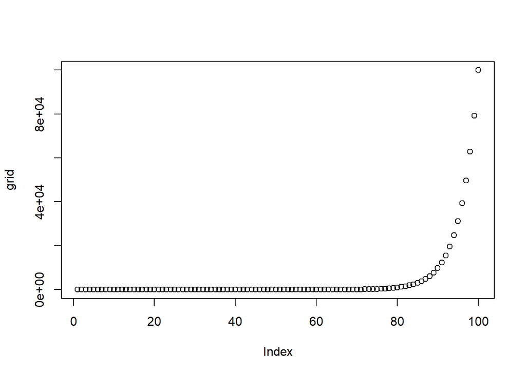

```r
plot(grid)
```

Then, we’ve applied the ridge regression for every $\lambda$ in the grid (each predictor is standardized before the model fitting, since $\hat{\beta}_{ridge}$ coefficients aren’t scale invariant as the $\hat{\beta}_{OLS}$).

As result, we get a vector of $\hat{\beta}_{ridge}$ coefficients estimates for each $\lambda$ values.

Plugging everything in a graph, we can see the behavior of the $\hat{\beta}_{ridge}$ as a function of $\lambda$.

As $\lambda$ increases, the $\hat{\beta}_{ridge}$ decreases, being equal zero in the limit case. While, if $\lambda$ is $0$ the $\hat{\beta}_{ridge}$ will be exactly equal to $\hat{\beta}_{OLS}$.

```r
ridge_grid=glmnet(X, y, alpha = 0, lambda = grid, standardize = TRUE)
coef_grid = coef(ridge_grid)
str(coef_grid)
```

```
## Formal class 'dgCMatrix' [package "Matrix"] with 6 slots
##   ..@ i       : int [1:2300] 0 1 2 3 4 5 6 7 8 9 ...
##   ..@ p       : int [1:101] 0 23 46 69 92 115 138 161 184 207 ...
##   ..@ Dim     : int [1:2] 23 100
##   ..@ Dimnames:List of 2
##   .. ..$ : chr [1:23] "(Intercept)" "X1" "X2" "X3" ...
##   .. ..$ : chr [1:100] "s0" "s1" "s2" "s3" ...
##   ..@ x       : num [1:2300] 6.01e+01 -1.85e-04 4.48e-05 -1.67e-04 -4.01e-05 ...
##   ..@ factors : list()
```

```r
ridge_grid$lambda
```

```
##   [1] 1.000000e+05 7.924829e+04 6.280291e+04 4.977024e+04 3.944206e+04
##   [6] 3.125716e+04 2.477076e+04 1.963041e+04 1.555676e+04 1.232847e+04
##  [11] 9.770100e+03 7.742637e+03 6.135907e+03 4.862602e+03 3.853529e+03
##  [16] 3.053856e+03 2.420128e+03 1.917910e+03 1.519911e+03 1.204504e+03
##  [21] 9.545485e+02 7.564633e+02 5.994843e+02 4.750810e+02 3.764936e+02
##  [26] 2.983647e+02 2.364489e+02 1.873817e+02 1.484968e+02 1.176812e+02
##  [31] 9.326033e+01 7.390722e+01 5.857021e+01 4.641589e+01 3.678380e+01
##  [36] 2.915053e+01 2.310130e+01 1.830738e+01 1.450829e+01 1.149757e+01
##  [41] 9.111628e+00 7.220809e+00 5.722368e+00 4.534879e+00 3.593814e+00
##  [46] 2.848036e+00 2.257020e+00 1.788650e+00 1.417474e+00 1.123324e+00
##  [51] 8.902151e-01 7.054802e-01 5.590810e-01 4.430621e-01 3.511192e-01
##  [56] 2.782559e-01 2.205131e-01 1.747528e-01 1.384886e-01 1.097499e-01
##  [61] 8.697490e-02 6.892612e-02 5.462277e-02 4.328761e-02 3.430469e-02
##  [66] 2.718588e-02 2.154435e-02 1.707353e-02 1.353048e-02 1.072267e-02
##  [71] 8.497534e-03 6.734151e-03 5.336699e-03 4.229243e-03 3.351603e-03
##  [76] 2.656088e-03 2.104904e-03 1.668101e-03 1.321941e-03 1.047616e-03
##  [81] 8.302176e-04 6.579332e-04 5.214008e-04 4.132012e-04 3.274549e-04
##  [86] 2.595024e-04 2.056512e-04 1.629751e-04 1.291550e-04 1.023531e-04
##  [91] 8.111308e-05 6.428073e-05 5.094138e-05 4.037017e-05 3.199267e-05
##  [96] 2.535364e-05 2.009233e-05 1.592283e-05 1.261857e-05 1.000000e-05
```

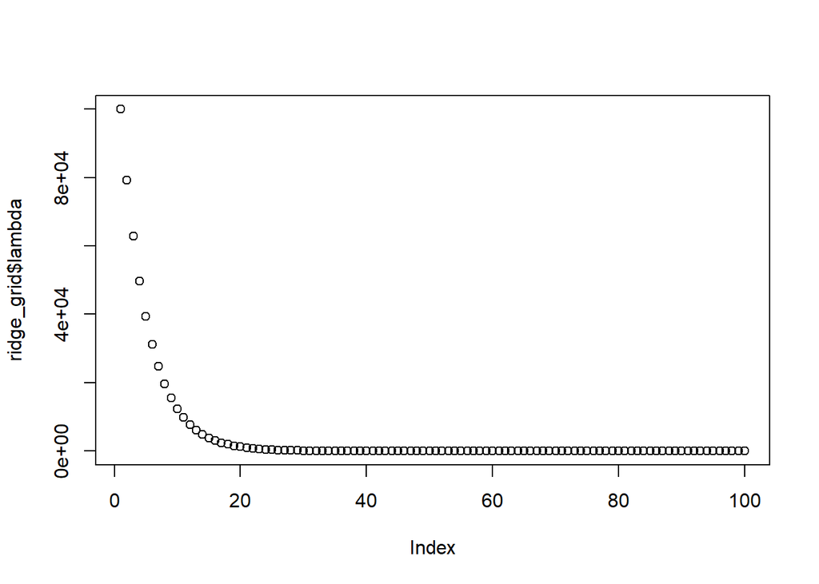

```r
plot(ridge_grid$lambda)
```

To select the $best$ $\lambda$, we’ve applied the $k$-$fold$ cross validation method and looked for the lambda value with the lowest $CV$-$error$.

```r
set.seed(5304201)
cv.out = cv.glmnet(X, y, lambda = grid, alpha = 0)
cv.out
```

```
##
## Call:  cv.glmnet(x = X, y = y, lambda = grid, alpha = 0)
##
## Measure: Mean-Squared Error
##
##     Lambda Index Measure    SE Nonzero
## min 0.3511    55   57.91 7.680      22
## 1se 2.8480    46   63.44 7.045      22
```

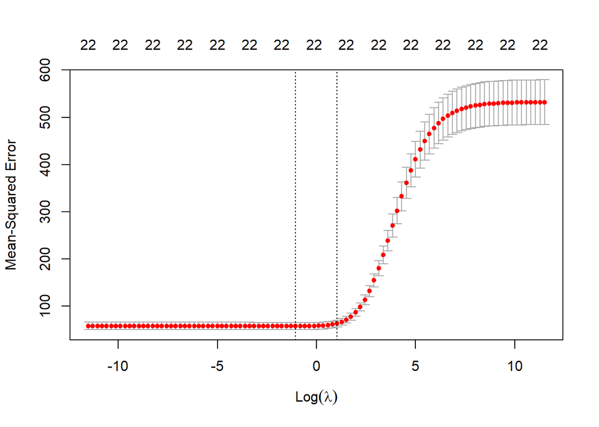

```r
plot(cv.out)
```

```r
bestlam = cv.out$lambda.min
bestlam
```

```
## [1] 0.3511192
```

0.3511192 is the $best$ $\lambda$ that we must use to find the best subset predictors.

So, in order to get the optimal model, we’ve fitted it, using the $best$ ($\lambda$) found.

```r
ridge_grid=glmnet(X, y, alpha = 0, lambda = bestlam, standardize = TRUE)
ridge_grid
```

```
##
## Call:  glmnet(x = X, y = y, alpha = 0, lambda = bestlam, standardize = TRUE)
##
##   Df  %Dev Lambda
## 1 22 91.05 0.3511
```

## PROBLEM 3

We’ve created a new categorical variable $Y$, called $score$ indicating whether the student is admitted $(1)$ or not $(0)$ to the second year, based on his final grade.

We’ve used an if-else loop to determine the value of $score$. If the final grade of the student is greater than or equal to $60$, $score$ is set to $1$; otherwise, it is set equal to $0$.

```r
score=ifelse( dataset$Y >= 60, 1, 0 )
score
```

```
##   [1] 1 1 0 0 0 1 1 1 0 1 1 1 1 1 0 1 0 0 1 0 1 0 1 0 1 0 1 0 1 0 1 0 0 0 0 1 0
##  [38] 0 1 1 1 1 0 0 0 1 0 1 1 0 0 1 1 1 0 1 0 1 0 0 0 0 0 0 0 1 1 0 1 0 0 1 1 0
##  [75] 1 1 0 1 1 1 0 0 1 0 1 1 0 0 1 0 1 1 0 1 1 0 1 0 0 0 0 1 1 0 0 0 1 1 0 1 1
## [112] 1 0 0 1 0 1 1 1 1 1 1 0 1 0 1 0 1 1 0 1 1 1 0 0 0 0 1 1 1 0 1 0 0 0 1 0 1
## [149] 0 1 1 1 0 0 1 0 0 0 1 0 0 1 0 1 0 0 1 0 0 0 1 0 1 0 1 0 0 1 1 1 0 1 1 0 1
## [186] 0 0 0 1 1 1 0 0 0 0 1 0 1 0 0 0 0 1 0 0 0 1 1 1 1 1 1 0 0 1 0 0 1 0 1 1 0
## [223] 0 1 1 0 0 1 0 0 0 1 1 0 0 0 1 0 1 0 1 0 1 0 0 0 1 1 1 1 0 1 1 0 0 1 0 0 0
## [260] 0
```

Then, we’ve applied a logistic regression model to predict the probability of admission for each student.

```r
out_glm=glm(score ~ X, family = binomial(link=logit))
out_glm
```

```
##
## Call:  glm(formula = score ~ X, family = binomial(link = logit))
##
## Coefficients:
## (Intercept)          XX1          XX2          XX3          XX4          XX5
##    41.63289     -0.28574      0.10276     -0.32265      0.02496     -0.05155
##         XX6          XX7          XX8          XX9         XX10         XX11
##     0.26945     -0.20609      0.00747      0.27637      0.03285     -0.35572
##        XX12         XX13         XX14         XX15         XX16         XX17
##    -0.04514     -0.29830      0.29157      3.39855      0.40513      2.62330
##        XX18         XX19         XX20         XX21         XX22
##     1.03601      4.49022      2.12616      3.62486      1.14764
##
## Degrees of Freedom: 259 Total (i.e. Null);  237 Residual
## Null Deviance:       360.2
## Residual Deviance: 64.41     AIC: 110.4
```

```r
summary(out_glm)
```

```
##
## Call:
## glm(formula = score ~ X, family = binomial(link = logit))
##
## Coefficients:
##             Estimate Std. Error z value Pr(>|z|)
## (Intercept) 41.63289   13.27513   3.136  0.00171 **
## XX1         -0.28574    0.07192  -3.973 7.10e-05 ***
## XX2          0.10276    0.04059   2.532  0.01135 *
## XX3         -0.32265    0.07747  -4.165 3.11e-05 ***
## XX4          0.02496    0.03440   0.726  0.46812
## XX5         -0.05155    0.03160  -1.631  0.10279
## XX6          0.26945    0.06558   4.109 3.98e-05 ***
## XX7         -0.20609    0.04918  -4.190 2.78e-05 ***
## XX8          0.00747    0.03371   0.222  0.82461
## XX9          0.27637    0.06681   4.137 3.52e-05 ***
## XX10         0.03285    0.03219   1.020  0.30758
## XX11        -0.35572    0.08310  -4.281 1.86e-05 ***
## XX12        -0.04514    0.03688  -1.224  0.22095
## XX13        -0.29830    0.07209  -4.138 3.51e-05 ***
## XX14         0.29157    0.06716   4.342 1.41e-05 ***
## XX15         3.39855    1.03589   3.281  0.00104 **
## XX16         0.40513    0.77440   0.523  0.60087
## XX17         2.62330    1.04144   2.519  0.01177 *
## XX18         1.03601    0.89497   1.158  0.24703
## XX19         4.49022    1.40447   3.197  0.00139 **
## XX20         2.12616    1.00284   2.120  0.03399 *
## XX21         3.62486    1.10966   3.267  0.00109 **
## XX22         1.14764    1.03410   1.110  0.26709
## ---
## Signif. codes:  0 '***' 0.001 '**' 0.01 '*' 0.05 '.' 0.1 ' ' 1
##
## (Dispersion parameter for binomial family taken to be 1)
##
##     Null deviance: 360.19  on 259  degrees of freedom
## Residual deviance:  64.41  on 237  degrees of freedom
## AIC: 110.41
##
## Number of Fisher Scoring iterations: 9
```

To find the estimated coefficients $\hat{\beta}$, we’ve used the Maximum Likelihood estimator. It makes us able to find the $\hat{\beta}$ that maximize the Likelihood function.

```r
beta_hat=out_glm$coefficients
beta_hat
```

```
##  (Intercept)          XX1          XX2          XX3          XX4          XX5
## 41.632885203 -0.285736099  0.102759115 -0.322651203  0.024956338 -0.051553642
##          XX6          XX7          XX8          XX9         XX10         XX11
##  0.269451376 -0.206089388  0.007470085  0.276371913  0.032847962 -0.355718903
##         XX12         XX13         XX14         XX15         XX16         XX17
## -0.045141388 -0.298301487  0.291573534  3.398546738  0.405133274  2.623301803
##         XX18         XX19         XX20         XX21         XX22
##  1.036013696  4.490217766  2.126156070  3.624856083  1.147638805
```

Once we’ve $\hat{\beta}$, we’ve plugged in the logit function. Doing the cross product between the transposed $\hat{\beta}$ vector and the matrix $X$ of all the correspond predictors, we’ve found $z$.

To get the estimated probabilities $\hat{\pi}_{i}$, we applied the inverse logit to $z$.

```r
xx=cbind(1,X)
z=xx%*%beta_hat
pi_hat=exp(z)/(1+exp(z))
head(pi_hat)
```

```
##           [,1]
## 1 9.325121e-01
## 2 9.999990e-01
## 3 1.421852e-07
## 4 8.245468e-04
## 5 1.658469e-04
## 6 9.996076e-01
```

Then we’ve provided a graphical comparison between the estimated probabilities and the true value of $Y$.

```r
col_lab= c()

col_lab[score==0] = "blue"
col_lab[score==1] = "red"

col_lab
```

```
##   [1] "red"  "red"  "blue" "blue" "blue" "red"  "red"  "red"  "blue" "red"
##  [11] "red"  "red"  "red"  "red"  "blue" "red"  "blue" "blue" "red"  "blue"
##  [21] "red"  "blue" "red"  "blue" "red"  "blue" "red"  "blue" "red"  "blue"
##  [31] "red"  "blue" "blue" "blue" "blue" "red"  "blue" "blue" "red"  "red"
##  [41] "red"  "red"  "blue" "blue" "blue" "red"  "blue" "red"  "red"  "blue"
##  [51] "blue" "red"  "red"  "red"  "blue" "red"  "blue" "red"  "blue" "blue"
##  [61] "blue" "blue" "blue" "blue" "blue" "red"  "red"  "blue" "red"  "blue"
##  [71] "blue" "red"  "red"  "blue" "red"  "red"  "blue" "red"  "red"  "red"
##  [81] "blue" "blue" "red"  "blue" "red"  "red"  "blue" "blue" "red"  "blue"
##  [91] "red"  "red"  "blue" "red"  "red"  "blue" "red"  "blue" "blue" "blue"
## [101] "blue" "red"  "red"  "blue" "blue" "blue" "red"  "red"  "blue" "red"
## [111] "red"  "red"  "blue" "blue" "red"  "blue" "red"  "red"  "red"  "red"
## [121] "red"  "red"  "blue" "red"  "blue" "red"  "blue" "red"  "red"  "blue"
## [131] "red"  "red"  "red"  "blue" "blue" "blue" "blue" "red"  "red"  "red"
## [141] "blue" "red"  "blue" "blue" "blue" "red"  "blue" "red"  "blue" "red"
## [151] "red"  "red"  "blue" "blue" "red"  "blue" "blue" "blue" "red"  "blue"
## [161] "blue" "red"  "blue" "red"  "blue" "blue" "red"  "blue" "blue" "blue"
## [171] "red"  "blue" "red"  "blue" "red"  "blue" "blue" "red"  "red"  "red"
## [181] "blue" "red"  "red"  "blue" "red"  "blue" "blue" "blue" "red"  "red"
## [191] "red"  "blue" "blue" "blue" "blue" "red"  "blue" "red"  "blue" "blue"
## [201] "blue" "blue" "red"  "blue" "blue" "blue" "red"  "red"  "red"  "red"
## [211] "red"  "red"  "blue" "blue" "red"  "blue" "blue" "red"  "blue" "red"
## [221] "red"  "blue" "blue" "red"  "red"  "blue" "blue" "red"  "blue" "blue"
## [231] "blue" "red"  "red"  "blue" "blue" "blue" "red"  "blue" "red"  "blue"
## [241] "red"  "blue" "red"  "blue" "blue" "blue" "red"  "red"  "red"  "red"
## [251] "blue" "red"  "red"  "blue" "blue" "red"  "blue" "blue" "blue" "blue"
```

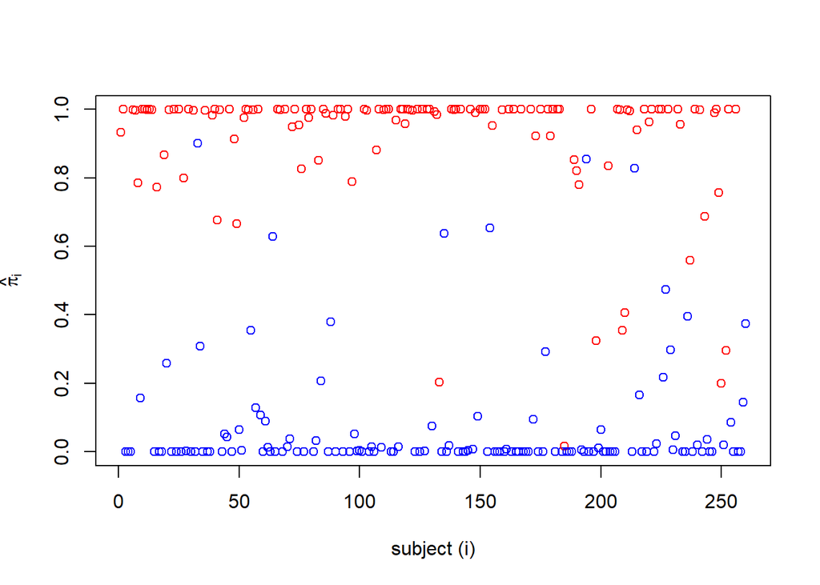

```r
plot(pi_hat, xlab = "subject (i)", ylab = expression(hat(pi)[i]), col = col_lab)
```

The graph has individuals on the x-axis and the probability of passing the exam on the y-axis. Red points represent all students who have a passing grade, (i.e. having a score above 60 and so $Y$ is 1), while for blue points, it’s the opposite. So basically, we can assess whether the probability is well estimated or not. In this case, it seems to be well estimated because the majority of students who passed the exam (the red points) are associated with high probabilities of passing it, and for the blue points, it’s the opposite.

Given the estimated probability $\hat{\pi}_{i}$, we aim to predict $\tilde{Y}_{i}$ by applying a threshold $k$ $∈$ $(0,1)$ to the estimated probability $\hat{\pi}_{i}$.

To this end, we have generated a sequence of $k$, ranging from $0.1$ to $0.9$ and for each $k$, we’ve computed the $Error Rate$$(ER)$.

Then, we’ve plugged them in a plot to observe the $Error Rate$ distribution with respect of the different $k$ values.

```r
k_values = seq(0.1, 0.9, by = 0.1)
k_values
```

```
## [1] 0.1 0.2 0.3 0.4 0.5 0.6 0.7 0.8 0.9
```

```r
error_rates = numeric(length(k_values))
y_hat= list()

for (i in 1:length(k_values)) {
  predicted_lables = ifelse(pi_hat >= k_values[i], 1, 0)
  y_hat[[i]] = predicted_lables

  error_rate = mean(predicted_lables != score)
  error_rates[i]=error_rate
}

error_rates
```

```
## [1] 0.09230769 0.07307692 0.06153846 0.05000000 0.05000000 0.05384615 0.05384615
## [8] 0.07692308 0.09615385
```

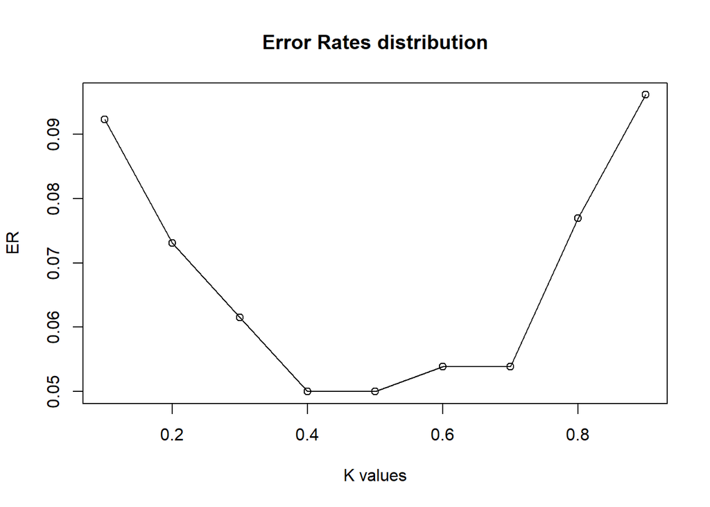

```r
plot(k_values, error_rates, type="o", xlab="K values", ylab="ER",  main="Error Rates distribution" )
```

At this point, we need to select the optimal $k$: it is the one leading to the minimum $ER$.

```r
optimal_k=k_values[which.min(error_rates)]
min_er=min(error_rates)
min_er
```

```
## [1] 0.05
```

```r
optimal_k
```

```
## [1] 0.4
```

The best value of $k$ is 0.4.

## PROBLEM 4

We first set up the input of our function: the $matrix_x$ is an $(n,q)$ matrix collecting $n$ observations of the available $q$ continuous predictors.

```r
library(mvtnorm)
set.seed(5304201)
col=dataset[,c(2:15)]
matrix_x=as.data.frame(col)
```

Then, we’ve set up the function as follow:

```r
lda_function <- function(X, y) {

  mu_hat0 <- colMeans(X[y == 0, ])
  mu_hat1 <- colMeans(X[y == 1, ])


  Sigma_hat <- cov(X)


  pi_1 <- mean(y==1)
  pi_0 <- 1 - pi_1

  n <- nrow(X)
  probs <- matrix(0, nrow = n, ncol = 2)


  for (i in 1:n) {
    prob0 <- dmvnorm(X[i, ], mean = mu_hat0, sigma = Sigma_hat)
    prob1 <- dmvnorm(X[i, ], mean = mu_hat1, sigma = Sigma_hat)


    posterior0 <- prob0 * pi_0
    posterior1 <- prob1 * pi_1


    probs[i, ] <- c(posterior0, posterior1)
  }

  return(probs)

}
```

In the function, we compute empirical means $\hat{\mu}_{0}$ and $\hat{\mu}_{1}$ and the empirical variance-covariance matrix $\hat{\Sigma}$ as estimators of the parameters required by $LDA$.

Our $\hat{\mu}$ are group dependent, meaning that they’re different in each group $(0,1)$ while the $\hat{\Sigma}$ is the same across groups.

Then we calculate the prior probabilities $\pi_{0}$ and $\pi_{1}$. After, we build up a matrix to store the posterior probabilities.

Using a for cycle, we compute the estimated posterior probabilities for each observation. In particular, we compute the probability density function (pdf) of a multivariate normal distribution for both classes (assumption of the Linear Discriminant Analysis).

Applying the Bayes’ rule, we calculate the estimated posterior probabilities for each $i$.

## POINT 5

We used the $X$ matrix, containing our $q$ continuous predictors, named $matrix_x$, and the $Y$ vector, indicating whether the student is admitted or not, named $score$.

```r
probs<-lda_function(matrix_x, score)
head(probs)
```

```
##              [,1]         [,2]
## [1,] 1.375411e-23 1.425860e-23
## [2,] 7.659992e-25 3.246371e-24
## [3,] 9.552945e-25 1.397222e-25
## [4,] 1.650626e-24 2.008556e-25
## [5,] 1.516372e-26 3.750163e-27
## [6,] 1.651962e-25 4.386246e-25
```

Using an if else statement, we assign to $\tilde{Y}$ a value of $1$ if the posterior probability for class $1$ is greater than or equal to the posterior probability for class $0$ ($Pr1$ >= $Pr0$), indicating that the student is predicted to be admitted. Otherwise, a value of $0$ is assigned, indicating that the student is predicted not to be admitted.

```r
pr0=probs[,1]
pr1=probs[,2]
y_tilda=ifelse(pr1 >= pr0 , 1, 0)
head(y_tilda)
```

```
## [1] 1 1 0 0 0 1
```

Now, we want to compare the $LDA$ results with the with those obtained using logistic regression at Point 3.

We compute $\tilde{Y}_{logit}$, applied the Logistic regression with the optimal $k$ found out in the point 3.  
We check if each value $\hat{\pi}_{i}$ is greater than, or equal to the optimal threshold $k$. If it is, $\tilde{Y}_{logit}$ is equal to $1$, indicating the positive class (e.g., admitted), otherwise, $\tilde{Y}_{logit}$ is $0$, indicating the negative class (e.g. not admitted).

```r
y_tilda.logit=ifelse(pi_hat>=optimal_k, 1, 0)
yt_logit = as.vector(y_tilda.logit)
head(yt_logit)
```

```
## [1] 1 1 0 0 0 1
```

Then we check if the two results are the same.

```r
check=ifelse(y_tilda==yt_logit, "Same result", "Different result")
check
```

```
##   [1] "Same result"      "Same result"      "Same result"
##   [4] "Same result"      "Same result"      "Same result"
##   [7] "Same result"      "Same result"      "Same result"
##  [10] "Same result"      "Same result"      "Different result"
##  [13] "Same result"      "Same result"      "Same result"
##  [16] "Same result"      "Same result"      "Same result"
##  [19] "Same result"      "Same result"      "Same result"
##  [22] "Same result"      "Different result" "Same result"
##  [25] "Same result"      "Same result"      "Same result"
##  [28] "Same result"      "Same result"      "Same result"
##  [31] "Same result"      "Same result"      "Same result"
##  [34] "Different result" "Same result"      "Same result"
##  [37] "Same result"      "Same result"      "Same result"
##  [40] "Same result"      "Different result" "Same result"
##  [43] "Same result"      "Same result"      "Same result"
```

[output cut: 72 more lines]

We observe some differences in the predictions.

Both $LDA$ and logistic regression are classification methods, meaning that they’re used when the response variable $Y$ is binary. With the logistic regression we model directly the conditioned probability of $Y$. We use the logit link function $\hat{\pi}_{i} =logit^{-1}(z)$ , and from this one, we predict $Y$.

On the other hand, in $LDA$, we need to recover the conditioned probability of $Y$ as follow: first, we need to model the joint distribution of the predictors and then we apply the Bayesian Theorem to get the conditioned probability of $Y$. $LDA$ operates under the assumption that within each group, the predictors follow a Multivariate Normal Distribution, with the same variance-covariance matrix in the Linear case. As a consequence, we have different parameters that we need to estimate : the mean within each group and the variance-covariance matrix.

So, why do we need $LDA$? Parameters estimates of logistic regression can be unstable when the number of observations is small and/or the classes are well separated. Instead, $Linear Discriminant Analysis$ is less sensitive to these issues and offers more reliable estimates.